# R Programming Lab Notebook

Knowledge Engineering Lab

Sanmitra Dharmavarapu

github url: https://github.com/sanmitraD/Knowledge-Engineering-Lab-coursework

# 1. Exploratory data analysis using R

Load the iris dataset and display the names and type of each column. Find statistics such as min, max, range, mean, median, variance and standard deviation for each column of data.

**Iris Data Set** Iris dataset os the best known dataset to be found in pattern recognition literature. The dataset contains 3 classes of 50 instances each, where each class refers to a type of iris plant.

*Attribute Information* 1. sepal length in cm

2. sepal width in cm
3. petal length in cm
4. petal width in cm
5. class
   - Iris Setosa
   - Iris Versicolour
   - Iris Virginica

```r
# the Iris dataset is an inbulit dataset avalable in RStudio and we can use it using iris identifier
print(iris)
```

| Sepal.Length | Sepal.Width | Petal.Length | Petal.Width | Species |
| --- | --- | --- | --- | --- |
| 5.1 | 3.5 | 1.4 | 0.2 | setosa |
| 4.9 | 3.0 | 1.4 | 0.2 | setosa |
| 4.7 | 3.2 | 1.3 | 0.2 | setosa |
| 4.6 | 3.1 | 1.5 | 0.2 | setosa |
| 5.0 | 3.6 | 1.4 | 0.2 | setosa |
| 5.4 | 3.9 | 1.7 | 0.4 | setosa |
| 4.6 | 3.4 | 1.4 | 0.3 | setosa |
| 5.0 | 3.4 | 1.5 | 0.2 | setosa |
| 4.4 | 2.9 | 1.4 | 0.2 | setosa |
| 4.9 | 3.1 | 1.5 | 0.1 | setosa |

[output cut: 140 more lines]

To display the names and types of each column

```r
# to display names of each column we use the names functon

print(names(iris))
```

```
[1] "Sepal.Length" "Sepal.Width"  "Petal.Length" "Petal.Width"  "Species"
```

For diplaying the names along with their types we use the lapply function using class as second argument

```r
print(lapply(iris,class))
```

```
$Sepal.Length
[1] "numeric"

$Sepal.Width
[1] "numeric"

$Petal.Length
[1] "numeric"

$Petal.Width
[1] "numeric"

$Species
[1] "factor"
```

*Finding the mean of individual columns*

```r
# we can find mean of a column using mean function

# we can refer to individual columns in a datset using $ symbol as showin below

print(mean(iris$Sepal.Length))
```

```
[1] 5.843333
```

```r
print(mean(iris$Sepal.Width))
```

```
[1] 3.057333
```

```r
print(mean(iris$Petal.Length))
```

```
[1] 3.758
```

```r
print(mean(iris$Petal.Width))
```

```
[1] 1.199333
```

*Finding the median of each column*

```r
# we can find median of a column using median function


print(median(iris$Sepal.Length))
```

```
[1] 5.8
```

```r
print(median(iris$Sepal.Width))
```

```
[1] 3
```

```r
print(median(iris$Petal.Length))
```

```
[1] 4.35
```

```r
print((median(iris$Petal.Width)))
```

```
[1] 1.3
```

*Finding maximum value of each column*

```r
# we can find maximum of a column using max function


print(max(iris$Sepal.Length))
```

```
[1] 7.9
```

```r
print(max(iris$Sepal.Width))
```

```
[1] 4.4
```

```r
print(max(iris$Petal.Length))
```

```
[1] 6.9
```

```r
print(max(iris$Petal.Width))
```

```
[1] 2.5
```

```r
# we can find maximum of a column using min function


print(min(iris$Sepal.Length))
```

```
[1] 4.3
```

```r
print(min(iris$Sepal.Width))
```

```
[1] 2
```

```r
print(min(iris$Petal.Length))
```

```
[1] 1
```

```r
print(min(iris$Petal.Width))
```

```
[1] 0.1
```

*Finding the range of each column* We use range() to finding the range of each column. It returns a vector containing the minimum and maximum of all the given arguments.

```r
print(range(iris$Sepal.Length))
```

```
[1] 4.3 7.9
```

```r
print(range(iris$Sepal.Width))
```

```
[1] 2.0 4.4
```

```r
print(range(iris$Petal.Length))
```

```
[1] 1.0 6.9
```

```r
print(range(iris$Petal.Width))
```

```
[1] 0.1 2.5
```

*Finding variance of each column* we use var() function to find the variance of each column

```r
print(var(iris$Sepal.Length))
```

```
[1] 0.6856935
```

```r
print(var(iris$Sepal.Width))
```

```
[1] 0.1899794
```

```r
print(var(iris$Petal.Length))
```

```
[1] 3.116278
```

```r
print(var(iris$Petal.Width))
```

```
[1] 0.5810063
```

*Finding standard deviation of each column* We use sd() function to find the variance of each column

```r
print(sd(iris$Sepal.Length))
```

```
[1] 0.8280661
```

```r
print(sd(iris$Sepal.Width))
```

```
[1] 0.4358663
```

```r
print(sd(iris$Petal.Length))
```

```
[1] 1.765298
```

```r
print(sd(iris$Petal.Width))
```

```
[1] 0.7622377
```

**using summary function** we can use summary() function to get all the above details in a single go.

```r
summary(iris)
```

```
  Sepal.Length    Sepal.Width
 Min.   :4.300   Min.   :2.000
 1st Qu.:5.100   1st Qu.:2.800
 Median :5.800   Median :3.000
 Mean   :5.843   Mean   :3.057
 3rd Qu.:6.400   3rd Qu.:3.300
 Max.   :7.900   Max.   :4.400
  Petal.Length    Petal.Width
 Min.   :1.000   Min.   :0.100
 1st Qu.:1.600   1st Qu.:0.300
 Median :4.350   Median :1.300
 Mean   :3.758   Mean   :1.199
 3rd Qu.:5.100   3rd Qu.:1.800
 Max.   :6.900   Max.   :2.500
       Species
 setosa    :50
 versicolor:50
 virginica :50
```

# 2. R program to normalize the variables into 0 to 1 scale using min-max normalization

the formula to achieve min max normalization is y = (x-min)/(max-min)

$$y=\frac{x-min}{max-min}$$

```r
#dummy data
x = sample(-100:100,50)
print("original data")
```

```
[1] "original data"
```

```r
print(x)
```

```
 [1] -26  39  70 -57 -47  12  75  23   3
[10] -41 -58  60 -17  72  46  92  48 -82
[19]  -7  59 -14 -62  24 -36  -3 -35 -19
[28]   5 -93  25  19 100 -77 -88 -45  54
[37] -44 -79  63  79 -61 -72 -84   6 -67
[46]  67 -90  84 -52  44
```

```r
maximum = max(x)
minimum = min(x)
normalized = (x-minimum)/(maximum-minimum)
print("Normalized data")
```

```
[1] "Normalized data"
```

```r
print(normalized)
```

```
 [1] 0.34715026 0.68393782 0.84455959
 [4] 0.18652850 0.23834197 0.54404145
 [7] 0.87046632 0.60103627 0.49740933
[10] 0.26943005 0.18134715 0.79274611
[13] 0.39378238 0.85492228 0.72020725
[16] 0.95854922 0.73056995 0.05699482
[19] 0.44559585 0.78756477 0.40932642
[22] 0.16062176 0.60621762 0.29533679
[25] 0.46632124 0.30051813 0.38341969
[28] 0.50777202 0.00000000 0.61139896
[31] 0.58031088 1.00000000 0.08290155
[34] 0.02590674 0.24870466 0.76165803
[37] 0.25388601 0.07253886 0.80829016
[40] 0.89119171 0.16580311 0.10880829
[43] 0.04663212 0.51295337 0.13471503
[46] 0.82901554 0.01554404 0.91709845
[49] 0.21243523 0.70984456
```

[figure not shown]

```r
#using par function to fix multiple graphs in same plot

par(mfrow=c(1,2))
hist(x,breaks = 10, xlab = "Data",col = "lightblue", )
hist(normalized, breaks = 10, xlab = "Normalized data", col = "yellow")
```

# 3.Generate histograms for any one variable and generate scatter plots for every pair of variables showing each species in different colour on iris dataset.

Generating histogram for any one variable let it be sepal length

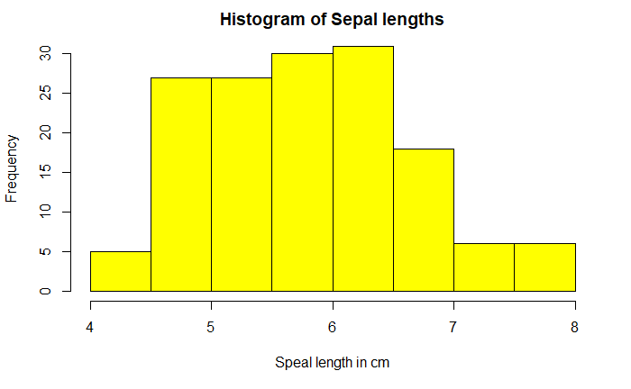

```r
hist(iris$Sepal.Length, col="yellow", xlab = "Speal length in cm", main = "Histogram of Sepal lengths")
```

Let us use red, green, blue as the colours for 3 species

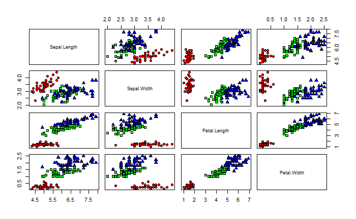

```r
my_cols=c("red","green","blue")
#21 is for circle, 22 is for squares 24 is for triangles
pairs(iris[1:4],pch=c(21,22,24)[iris$Species],bg=my_cols[iris$Species])
```

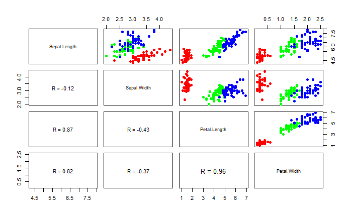

```r
#correlation panel
panel.cor = function(x,y){
  usr<- par("usr");on.exit(par(usr))
  par(usr = c(0,1,0,1))
  r = round(cor(x,y), digits = 2)
  txt = paste0("R = ",r)
  cex.cor = 0.8/strwidth(txt)
  text(0.5,0.5,txt,cex=cex.cor*r)
}

#customizing panels and printing correlations
#customize upper panel
upper.panel = function(x,y){
  points(x,y,pch=19,col=my_cols[iris$Species])
}

#create the plots
pairs(iris[1:4],lower.panel = panel.cor, upper.panel = upper.panel)
```

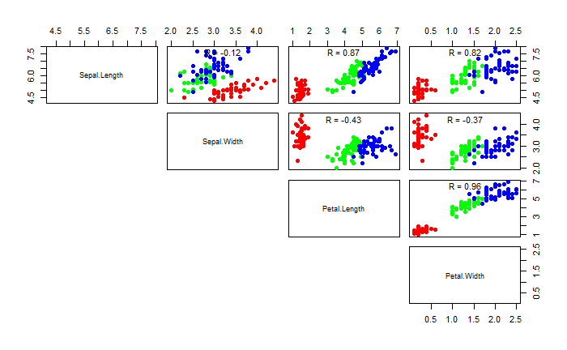

```r
#customize upper panel
upper.panel = function(x,y){
  points(x,y,pch=19,col = my_cols[iris$Species])
  r = round(cor(x,y),digits=2)
  txt = paste0("R = ",r)
  usr = par("usr");on.exit(par(usr))
  par(usr = c(0,1,0,1))
  text(0.5,0.9,txt)
}

pairs(iris[1:4],lower.panel = NULL,upper.panel = upper.panel)
```

```r
NA
NA
```

# 4. Generate box plots for each of the numerical attribute. Identify the attribute with highest variance.

We will be using buliting dataset “airquality” dataset for this program. It is a Daily air quality measurements in New York, May to September 1973.

Finding variance is simple. The spread of the boxplot indicates the variance. The more the spread of boxplot then it have more variance.

```r
#str(airquality)
#Here we dont need the Day and Month values
#removing rows with null values
#boxplot does not consider the null values (NAs) so no need to remove them
airq = airquality[1:4]
str(airq)
```

```
'data.frame':   153 obs. of  4 variables:
 $ Ozone  : int  41 36 12 18 NA 28 23 19 8 NA ...
 $ Solar.R: int  190 118 149 313 NA NA 299 99 19 194 ...
 $ Wind   : num  7.4 8 12.6 11.5 14.3 14.9 8.6 13.8 20.1 8.6 ...
 $ Temp   : int  67 72 74 62 56 66 65 59 61 69 ...
```

[figure not shown]

As we can see Solar.R which refers to Solar Radiation has more area of spread. Hence it has greater variance compared to other attributes

# 5.Study of homogeneous and heterogeneous data structures such as vector, matrix, array, list and dataframe in R.

**Vector**

Vector is a basic data structure in R that contains the element of similar type.The data types of components of vector can be logical, integer, double, character, complex or raw.

```r
#Creating a vector
studentname = c("Sanmitra", "Dharmavarapu")
print(studentname)
```

```
[1] "Sanmitra"     "Dharmavarapu"
```

```r
#Getting the class of the vector
print(class(studentname))
```

```
[1] "character"
```

**Lists** A list is an R object that can contain many different type of components in it. The components can vectors, fuctions and even another list and many more.

```r
#Creating a list.
list = list(c("Sanmitra","Dharmavarapu"),"CSE",316129510013,sin)
print(list)
```

```
[[1]]
[1] "Sanmitra"     "Dharmavarapu"

[[2]]
[1] "CSE"

[[3]]
[1] 316129510013

[[4]]
function (x)  .Primitive("sin")
```

**Matrices**

A matrix is a two dimensional reactangular data structure that contain list of homogeneous data in tabular format.It is possible to perform arithmetic operations on whole or a part of a matrix. A matrix can created using a vector input to the matrix() function

```r
print(M)
```

```
     [,1] [,2] [,3] [,4] [,5]
[1,]    1    2    3    4    5
[2,]    6    7    8    9   10
```

**Array** While matrices are confined to two dimensions, arrays can be of any number of dimensions.It can store data in more than one dimensions.

For example if we create an array of dimension(10,20,30) then it creates 30 matrices each with 10 rows and 20 columns. These can store elements of only type.

```r
v1 = c(1,2,3)
v2 = c(4,5,6,7,8,9)

arr = array(c(v1,v2),dim=c(3,3,2))
print(arr)
```

```
, , 1

     [,1] [,2] [,3]
[1,]    1    4    7
[2,]    2    5    8
[3,]    3    6    9

, , 2

     [,1] [,2] [,3]
[1,]    1    4    7
[2,]    2    5    8
[3,]    3    6    9
```

**Data Frames**

Data frame is a tabular data object or two dimensional array like structure in which each column, contains values of one variable and each row contains one set of values from each column.

Unlike matrices, each column of a data frame can contain different modes of data.

```r
costs = data.frame(
  name = c("carrot","apple","sugar"),
  costPerKG = c(50.00,60.00,39.50),
  QuantityAvailableinKGs = c(10,5,50))
print(costs)
```

| name | costPerKG | QuantityAvailableinKGs |
| --- | --- | --- |
| carrot | 50.0 | 10 |
| apple | 60.0 | 5 |
| sugar | 39.5 | 50 |

# 6. R program using **apply** group of functions to create and apply normalization function on each of te numerical columns of iris dataset to tranform them into a value around 0 with z-score normalization.

we can achive z-score normalization in R by using function *scale(X,center=TRUE, scale=TRUE)* where X refers to data.

So we need to apply it to all the columns in iris dataset which has numeric data. to do that we use apply() function

```r
str(iris)
```

```
'data.frame':   150 obs. of  5 variables:
 $ Sepal.Length: num  5.1 4.9 4.7 4.6 5 5.4 4.6 5 4.4 4.9 ...
 $ Sepal.Width : num  3.5 3 3.2 3.1 3.6 3.9 3.4 3.4 2.9 3.1 ...
 $ Petal.Length: num  1.4 1.4 1.3 1.5 1.4 1.7 1.4 1.5 1.4 1.5 ...
 $ Petal.Width : num  0.2 0.2 0.2 0.2 0.2 0.4 0.3 0.2 0.2 0.1 ...
 $ Species     : Factor w/ 3 levels "setosa","versicolor",..: 1 1 1 1 1 1 1 1 1 1 ...
```

```r
#We are using apply function to implement scale() function on every column.
#Here 2 means column
#It indicates apply function to apply scale() function column wise.
apply(iris[1:4], 2, scale)
```

```
       Sepal.Length Sepal.Width Petal.Length   Petal.Width
  [1,]  -0.89767388  1.01560199  -1.33575163 -1.3110521482
  [2,]  -1.13920048 -0.13153881  -1.33575163 -1.3110521482
  [3,]  -1.38072709  0.32731751  -1.39239929 -1.3110521482
  [4,]  -1.50149039  0.09788935  -1.27910398 -1.3110521482
  [5,]  -1.01843718  1.24503015  -1.33575163 -1.3110521482
  [6,]  -0.53538397  1.93331463  -1.16580868 -1.0486667950
  [7,]  -1.50149039  0.78617383  -1.33575163 -1.1798594716
  [8,]  -1.01843718  0.78617383  -1.27910398 -1.3110521482
  [9,]  -1.74301699 -0.36096697  -1.33575163 -1.3110521482
 [10,]  -1.13920048  0.09788935  -1.27910398 -1.4422448248
 [11,]  -0.53538397  1.47445831  -1.27910398 -1.3110521482
 [12,]  -1.25996379  0.78617383  -1.22245633 -1.3110521482
 [13,]  -1.25996379 -0.13153881  -1.33575163 -1.4422448248
 [14,]  -1.86378030 -0.13153881  -1.50569459 -1.4422448248
```

[output cut: 136 more lines]

As you can see that whole data is centered aroung 0

# 7.Apply Linear regression to

## a)predict evaporation coefficient in terms of air velociy using the given data

given data

| attributes | values |  |  |  |  |  |  |  |  |  |
| --- | --- | --- | --- | --- | --- | --- | --- | --- | --- | --- |
| Velocity (cm/s) | 20 | 60 | 100 | 140 | 180 | 220 | 260 | 300 | 340 | 380 |
| Evaporation (mm2/s) | 0.18 | 0.37 | 0.35 | 0.78 | 0.56 | 0.75 | 1.18 | 1.36 | 1.17 | 1.65 |

```r
x = c(20,60,100,140,180,220,260,300,340,380)
y = c(0.18,0.37, 0.35, 0.78, 0.56, 0.75, 1.18, 1.36, 1.17, 1.65)
#lm is a function to create a LINEAR MODEL
linearModel = lm(y~x)
print(linearModel)
```

```
Call:
lm(formula = y ~ x)

Coefficients:
(Intercept)            x
   0.069242     0.003829
```

```r
#now we create a new dataframe that set the x value
pdata = data.frame(x=400)

#we now apply predict() function and set the predictor variable in the pdata argument.

result = predict(linearModel,pdata)
print(result)
```

```
       1
1.600758
```

```r
#we can also set the interval type as "predict" with out changing the default 0.95 confidence level

result = predict(linearModel,pdata,interval = "predict")
print(result)
```

```
       fit      lwr      upr
1 1.600758 1.166314 2.035201
```

lwr and upr refers to the lower and upper bound of result.

```r
m1 = lm(dist ~ speed, data=cars)
summary(m1)
```

[output not shown]

```r
summary.aov(m1) # To get the sums of squares and mean squares
```

[output not shown]

```r
#calculate sums of squares total, residual and model

y = cars$dist
ybar = mean(y)
#ss is sum of squares
ss.total = sum((y-ybar)^2)
print(ss.total)
```

```
[1] 32538.98
```

```r
ss.residual= sum((y-m1$fitted)^2)
print(ss.residual)
```

```
[1] 11353.52
```

```r
ss.model = ss.total-ss.residual
print(ss.model)
```

```
[1] 21185.46
```

```r
#calculate degrees of freedom total, residual and model

n = length(cars$speed)
k = length(m1$coef)
print("k")
```

```
[1] "k"
```

```r
print(k)
```

```
[1] 2
```

```r
df.total = n-1
df.residual = n-k
df.model = k-1

# calcuating mean squres
ms.residual = ss.residual/df.residual
print(ms.residual)
```

```
[1] 236.5317
```

```r
ms.model = ss.model/df.model
print(ms.model)
```

```
[1] 21185.46
```

### c)Perform a log transformation on the “Air Velocity” column, perform linear regression again and analyze all the relevant values.

```r
#air velocity
x = c(20,60,100,140,180,220,260,300,340,380)
#evaporation coefficient
y = c(0.18,0.37, 0.35, 0.78, 0.56, 0.75, 1.18, 1.36, 1.17, 1.65)
x = log(x)
linearModel = lm(y~x)
print(linearModel)
```

```
Call:
lm(formula = y ~ x)

Coefficients:
(Intercept)            x
     -1.457        0.456
```

```r
#now we create a new dataframe that set the x value
pdata = data.frame(x=400)

#we now apply predict() function and set the predictor variable in the pdata argument.

result = predict(linearModel,pdata)
print(result)
```

```
       1
180.9577
```

```r
#we can also set the interval type as "predict" with out changing the default 0.95 confidence level

result = predict(linearModel,pdata,interval = "predict")
print(result)
```

```
       fit      lwr     upr
1 180.9577 92.97031 268.945
```

# 8. R program using apply group of functions to create and apply normalization function on each of te numeric variables/columns of iris dataset to tranform them into a value around 0 with z-score normalization.

we can achive z-score normalization in R by using function *scale(X,center=TRUE, scale=TRUE)* where X refers to data.

So we need to apply it to all the columns in iris dataset which has numeric data. to do that we use apply() function

```r
#We are using apply function to implement scale() function on every column.
#Here 2 means column
#It indicates apply function to apply scale() function column wise.
apply(iris[1:4], 2, scale)
```

```
       Sepal.Length Sepal.Width Petal.Length   Petal.Width
  [1,]  -0.89767388  1.01560199  -1.33575163 -1.3110521482
  [2,]  -1.13920048 -0.13153881  -1.33575163 -1.3110521482
  [3,]  -1.38072709  0.32731751  -1.39239929 -1.3110521482
  [4,]  -1.50149039  0.09788935  -1.27910398 -1.3110521482
  [5,]  -1.01843718  1.24503015  -1.33575163 -1.3110521482
  [6,]  -0.53538397  1.93331463  -1.16580868 -1.0486667950
  [7,]  -1.50149039  0.78617383  -1.33575163 -1.1798594716
  [8,]  -1.01843718  0.78617383  -1.27910398 -1.3110521482
  [9,]  -1.74301699 -0.36096697  -1.33575163 -1.3110521482
 [10,]  -1.13920048  0.09788935  -1.27910398 -1.4422448248
 [11,]  -0.53538397  1.47445831  -1.27910398 -1.3110521482
 [12,]  -1.25996379  0.78617383  -1.22245633 -1.3110521482
 [13,]  -1.25996379 -0.13153881  -1.33575163 -1.4422448248
 [14,]  -1.86378030 -0.13153881  -1.50569459 -1.4422448248
```

[output cut: 136 more lines]

As you can see that whole data is centered aroung 0.